# seaborn常见用法

```python
import seaborn as sns
import matplotlib.pyplot as plt
import numpy as np
import pandas as pd
%matplotlib inline
```

- %matplotlib inline是一个魔法函数（Magic Functions）。官方给出的定义是：IPython有一组预先定义好的所谓的魔法函数（Magic Functions），你可以通过命令行的语法形式来访问它们。
- 由于 %matplotlib inline 的存在，当输入plt.plot(x,y_1)后，不必再输入 plt.show()，图像将自动显示出来。

```python
titanic=sns.load_dataset("titanic") #此处读取的Titanic数据类型是DataFrame
#如果加载数据出错，可能是网络问题，等会儿就好
```

```python
titanic.shape
```

```
(891, 15)
```

```python
titanic.head(10)
```

|  | survived | pclass | sex | age | sibsp | parch | fare | embarked | class | who | adult_male | deck | embark_town | alive | alone |
| --- | --- | --- | --- | --- | --- | --- | --- | --- | --- | --- | --- | --- | --- | --- | --- |
| 0 | 0 | 3 | male | 22.0 | 1 | 0 | 7.2500 | S | Third | man | True | NaN | Southampton | no | False |
| 1 | 1 | 1 | female | 38.0 | 1 | 0 | 71.2833 | C | First | woman | False | C | Cherbourg | yes | False |
| 2 | 1 | 3 | female | 26.0 | 0 | 0 | 7.9250 | S | Third | woman | False | NaN | Southampton | yes | True |
| 3 | 1 | 1 | female | 35.0 | 1 | 0 | 53.1000 | S | First | woman | False | C | Southampton | yes | False |
| 4 | 0 | 3 | male | 35.0 | 0 | 0 | 8.0500 | S | Third | man | True | NaN | Southampton | no | True |
| 5 | 0 | 3 | male | NaN | 0 | 0 | 8.4583 | Q | Third | man | True | NaN | Queenstown | no | True |
| 6 | 0 | 1 | male | 54.0 | 0 | 0 | 51.8625 | S | First | man | True | E | Southampton | no | True |
| 7 | 0 | 3 | male | 2.0 | 3 | 1 | 21.0750 | S | Third | child | False | NaN | Southampton | no | False |
| 8 | 1 | 3 | female | 27.0 | 0 | 2 | 11.1333 | S | Third | woman | False | NaN | Southampton | yes | False |
| 9 | 1 | 2 | female | 14.0 | 1 | 0 | 30.0708 | C | Second | child | False | NaN | Cherbourg | yes | False |

```python
titanic.isnull().sum(axis=0)#axis=0表示列
```

```
survived         0
pclass           0
sex              0
age            177
sibsp            0
parch            0
fare             0
embarked         2
class            0
who              0
adult_male       0
deck           688
embark_town      2
alive            0
alone            0
dtype: int64
```

```python
??pd.DataFrame.dropna
```

#### 将age列选取出来返回为一个Series，并且丢掉其中的空值

```python
age1=titanic['age'].dropna()
```

```python
age1.isnull().sum()
```

```
0
```

## 直方图 sns.distplot()

#### 画出age字段的直方图,类似于matplotlib的hist

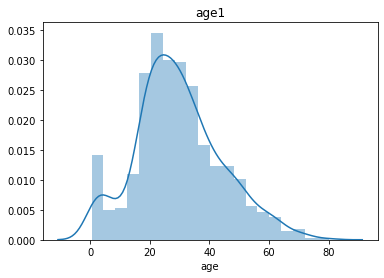

```python
sns.distplot(age1)
plt.title('age1')
```

- distplot默认画出核密度估计曲线，可以通过设置参数kde=False，选择不显示密度曲线
- 通过bins参数设定数据片段的数量，控制直方图面元的数量，输入int
- rug参数用于控制直方图中是否显示边际毛毯图，默认为False

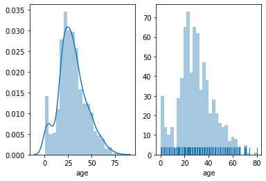

```python
fig,axes=plt.subplots(1,2)
sns.distplot(age1,ax=axes[0])
sns.distplot(age1,kde=False,bins=30,rug=True,ax=axes[1])
```

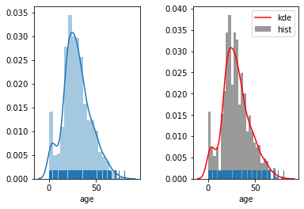

```python
fig,axes=plt.subplots(1,2)
sns.distplot(age1,rug=True,ax=axes[0])
sns.distplot(age1,bins=30,rug=True,ax=axes[1],
            hist_kws={'color':'k','label':'hist'},
            kde_kws={'color':'r','label':'kde'})
plt.subplots_adjust(wspace =0.5, hspace =0) #调整子图间距
```

> 注意这里设置kws参数输入的为一个字典，不要和matplotlib里设置参数取值的格式混淆 plot(color='k')

## barplot 条形图

条形图表示数值变量与每个矩形高度的中心趋势的估计值，默认显示均值，并使用误差线提供关于该估计值附近的不确定性的一些指示

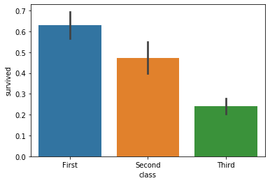

```python
#将分类变量船舱等级设为x轴进行分组，‘survived’数据字段放在y轴为数据分布
sns.barplot(x='class',y='survived',data=titanic)
```

> 关于图像的解释：Seaborn会按照分类字段对进行数据字段归类后按照 estimator 参数的方法（默认为平均值）计算相应的值， 计算出来的值就作为条形图所显示的值（条形图上的误差棒则表示 各类的数值相对于条形图所显示的值的误差）

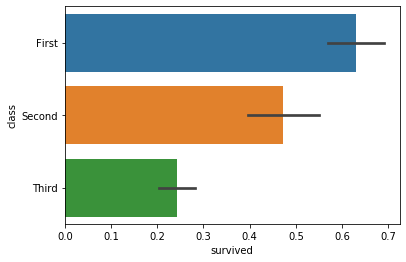

```python
sns.barplot(x='survived',y='class',data=titanic)
```

- hue: 把x轴的类别进行细分
- order:各类别取值的绘图顺序
- palette:调色板

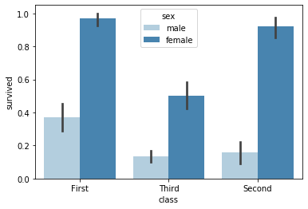

```python
sns.barplot(x='class',y='survived',data=titanic,order=['First','Third','Second'],
            hue='sex',palette='Blues')
```

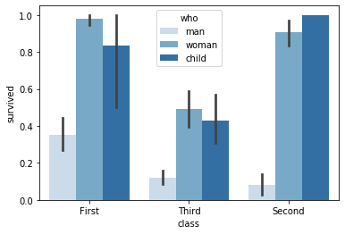

```python
sns.barplot(x='class',y='survived',data=titanic,order=['First','Third','Second'],
            hue='who',palette='Blues')
```

## boxplot 箱型图

我们来探索不同的'class'（船舱）下乘客的'age'（年龄）情况。

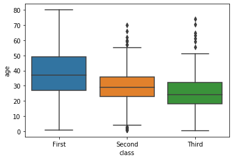

```python
sns.boxplot(x='class',y='age',data=titanic)
```

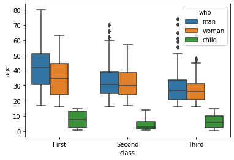

```python
sns.boxplot(x='class',y='age',hue='who',data=titanic)
```

- 调节'order' 和 'hue_order' 参数，我们可以控制x轴展示的顺序。

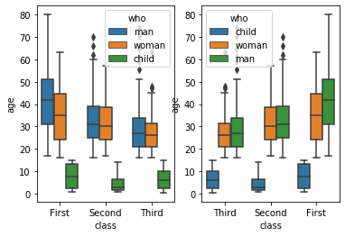

```python
fig,axes=plt.subplots(1,2)

sns.boxplot(x='class',y='age',hue='who',
                    data=titanic,ax=axes[0])

sns.boxplot(x='class',y='age',hue='who',data=titanic,
                    order=['Third','Second','First'],
                    hue_order=['child','woman','man'],ax=axes[1])
```

```python
fig,axes
```

[output not shown]

## violinplot 小提琴图

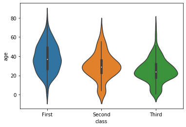

```python
sns.violinplot(x='class',y='age',data=titanic)
```

> 小提琴图可以看作箱型图与核密度图的结合，箱型图展示了分位数的位置，小提琴图则展示了任意位置的密度，通过小提琴图可以知道哪些位置的密度较高。 在图中，白点是中位数，黑色盒型的范围是下四分位点到上四分位点，细黑线表示须。外部形状即为核密度估计。
- 小提琴图也可以设置hue参数，按需使用。如果hue参数只有两类，也可以设置‘split’为True，拆分小提琴左右分别是两类

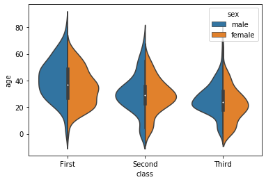

```python
sns.violinplot(x='class',y='age',hue='sex',split=True,data=titanic)
```

- 我们可以在小提琴内部添加图形来帮助我们进行分析，这里就需要控制'inner'参数

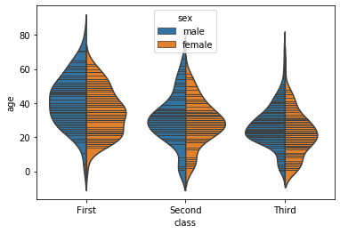

```python
sns.violinplot(x='class',y='age',hue='sex',split=True,inner='stick',data=titanic)
```

## regplot 回归图

```python
iris=sns.load_dataset('iris')
iris.sample(10)
```

|  | sepal_length | sepal_width | petal_length | petal_width | species |
| --- | --- | --- | --- | --- | --- |
| 148 | 6.2 | 3.4 | 5.4 | 2.3 | virginica |
| 14 | 5.8 | 4.0 | 1.2 | 0.2 | setosa |
| 124 | 6.7 | 3.3 | 5.7 | 2.1 | virginica |
| 120 | 6.9 | 3.2 | 5.7 | 2.3 | virginica |
| 117 | 7.7 | 3.8 | 6.7 | 2.2 | virginica |
| 83 | 6.0 | 2.7 | 5.1 | 1.6 | versicolor |
| 28 | 5.2 | 3.4 | 1.4 | 0.2 | setosa |
| 64 | 5.6 | 2.9 | 3.6 | 1.3 | versicolor |
| 62 | 6.0 | 2.2 | 4.0 | 1.0 | versicolor |
| 60 | 5.0 | 2.0 | 3.5 | 1.0 | versicolor |

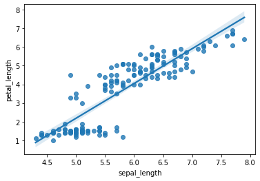

```python
sns.regplot(x='sepal_length',y='petal_length',data=iris)
```

> 图中的点表示实际的数据点，Seaborn 根据这些数据拟合出直线，表示x轴和y轴对应字段之间的线性关系，直线周围的阴影表示置信区间。 关于置信区间，可以通过设置'ci'参数控制是否显示。

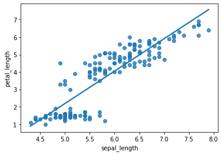

```python
sns.regplot(x='sepal_length',y='petal_length',data=iris,ci=None)
```

- 可以通过'color'和'marker'参数来控制图形的颜色以及数据点的形状

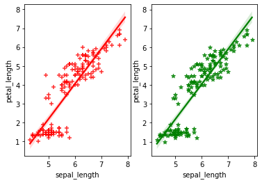

```python
fig,axes=plt.subplots(1,2)

sns.regplot(x='sepal_length',y='petal_length',data=iris,
            color='r',marker='+',ax=axes[0])

sns.regplot(x='sepal_length',y='petal_length',data=iris,
            color='g',marker='*',ax=axes[1])
```

lmplot() 可以设置hue，进行多个类别的显示，而 regplot() 是不支持的。这里我们通过设置hue='species'，来进行分类别地展示。我们也可以更改数据点的形状，来进行区分。

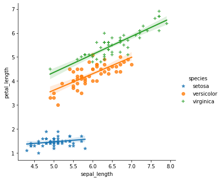

```python
sns.lmplot(x='sepal_length',y='petal_length',hue='species',
                    data=iris,markers=['*','o','+'])
```

- 设置'fit_reg'参数，可以控制是否显示拟合的直线

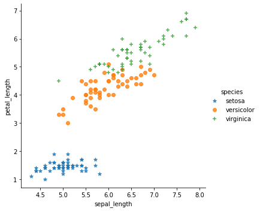

```python
sns.lmplot(x='sepal_length',y='petal_length',hue='species',
                data=iris,markers=['*','o','+'],fit_reg=False)
```

- 如果要对不同的类别分开绘制，用'col'参数代替'hue'

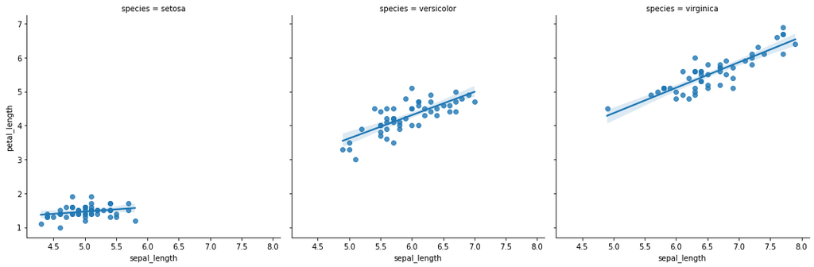

```python
sns.lmplot(x='sepal_length',y='petal_length',
                col='species',data=iris)
```

## heatmap 热力图

热力图可以把二维数组的值进行可视化显示

```python
flights = sns.load_dataset('flights')
flights.head(10)
```

|  | year | month | passengers |
| --- | --- | --- | --- |
| 0 | 1949 | January | 112 |
| 1 | 1949 | February | 118 |
| 2 | 1949 | March | 132 |
| 3 | 1949 | April | 129 |
| 4 | 1949 | May | 121 |
| 5 | 1949 | June | 135 |
| 6 | 1949 | July | 148 |
| 7 | 1949 | August | 148 |
| 8 | 1949 | September | 136 |
| 9 | 1949 | October | 119 |

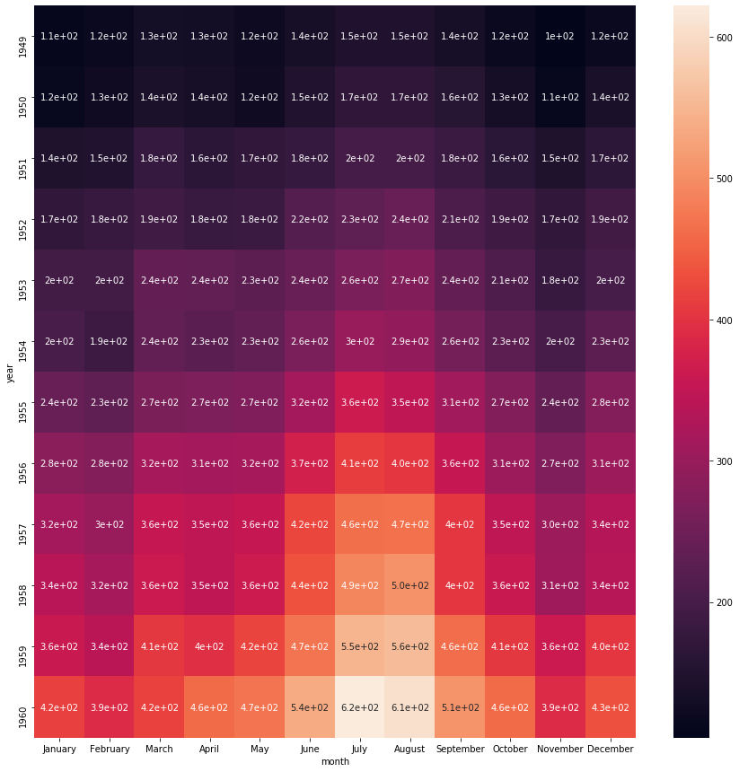

```python
data=flights.pivot(index='year',columns='month',values='passengers')
plt.figure(figsize=(15,15))
sns.heatmap(data,annot=True)
```

热力图最典型的应用场景就是用来表示特征之间的相关性， 一般通过颜色的深浅来表示数值的大小或者相关性的高低。

```python
coef_mat=iris.corr()
```

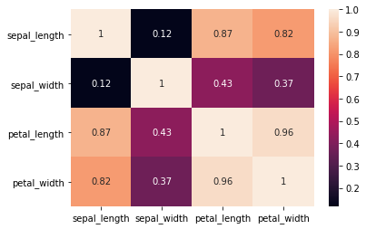

```python
sns.heatmap(np.abs(coef_mat),annot=True)
```

## 关于seaborn样式的一些设置

```python
# 指定默认字体
plt.rcParams['font.sans-serif'] = ['SimHei']

# 解决保存图像是负号'-'显示为方块的问题
plt.rcParams['axes.unicode_minus']=False
```

```python
??plt.rcParams
```

```python
??sns.set_style
```

> 可以看到style参数可以输入dict, None, or one of {darkgrid, whitegrid, dark, white, ticks} 通过绘制子图观察效果

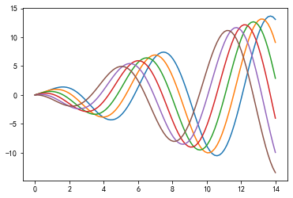

```python
def sinplot(flip=1):
    x = np.linspace(0, 14, 100)
    for i in range(1, 7):
        plt.plot(x, np.sin(x+i*0.5)*x)
sinplot()
```

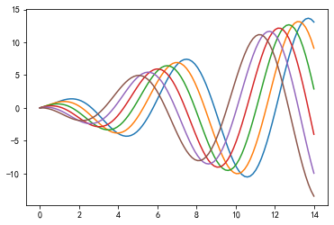

```python
def sinplot(flip=1):
    x = np.linspace(0, 14, 100)
    for i in range(1, 7):
        plt.plot(x, np.sin(x+i*0.5)*x)
sinplot()
```

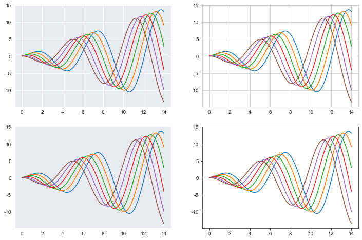

```python
plt.figure(figsize=(12, 8))
sns.set_style('darkgrid')
plt.subplot(221)#在两行两列的画布中位于第一个位置（左上角）
sinplot()

sns.set_style('whitegrid')
plt.subplot(222)#在两行两列的画布中位于第2个位置（右上角）
sinplot()

sns.set_style('dark')
plt.subplot(223)#在两行两列的画布中位于第3个位置（左下角）
sinplot()

sns.set_style('ticks')
plt.subplot(224)#在两行两列的画布中位于第4个位置（右下角）
sinplot()
```

### 调色板 主要用 color_palette() 函数控制

- 6个默认的颜色循环主题分别为：deep, muted, pastel, bright, dark, colorblind
- 2个渐变色：Reds，Blues

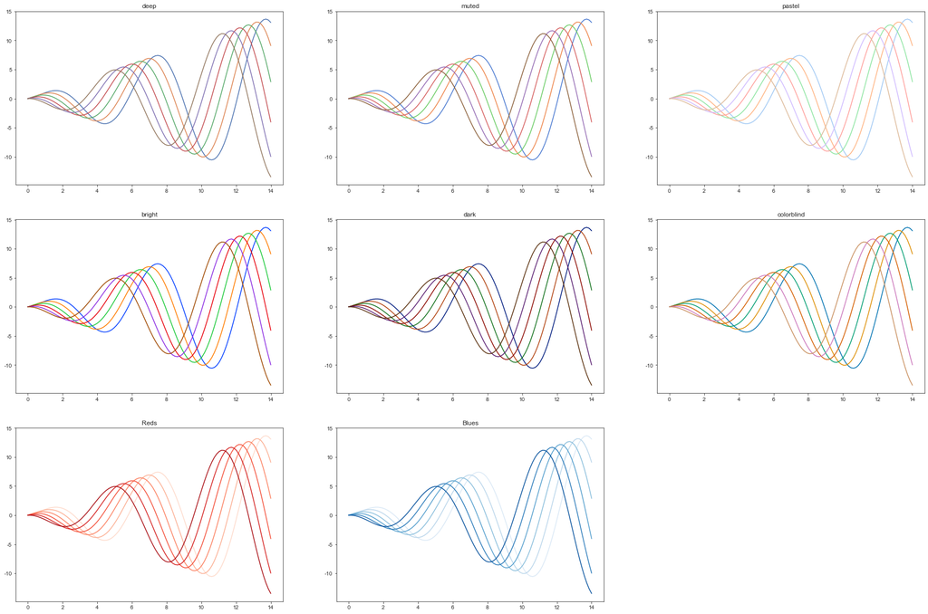

```python
plt.figure(figsize=(30,20))
for i,j in enumerate(['deep', 'muted', 'pastel', 'bright', 'dark', 'colorblind','Reds','Blues']):
    sns.set_palette(j)
    plt.subplot(3,3,i+1)
    plt.title(j)
    sinplot()
```

```python
#创建一个20行6列的数据
data = np.random.normal(size=(20, 6)) + np.arange(6) / 2
sns.boxplot(data=data,palette=sns.color_palette('Blues'))
```

[output not shown]